# Car Selling Price

Prediction Intervals Regression Line Checking the Assumptions Box Cox Applying the Transformation Understanding the Model Revaluating Assumptions

[figure not shown]

**2019 Toyota Corolla SE**

## Selling Point

The car being researched is a 2019 Toyota Corolla SE. It was initially bought in 2020 for $20,000 with 18,000 miles previously driven. This is the point marked in blue. I plan to sell my car at 125,000 miles. At this point in the regression, it is estimated to be sold at a price of $12,465, which is shown in green.

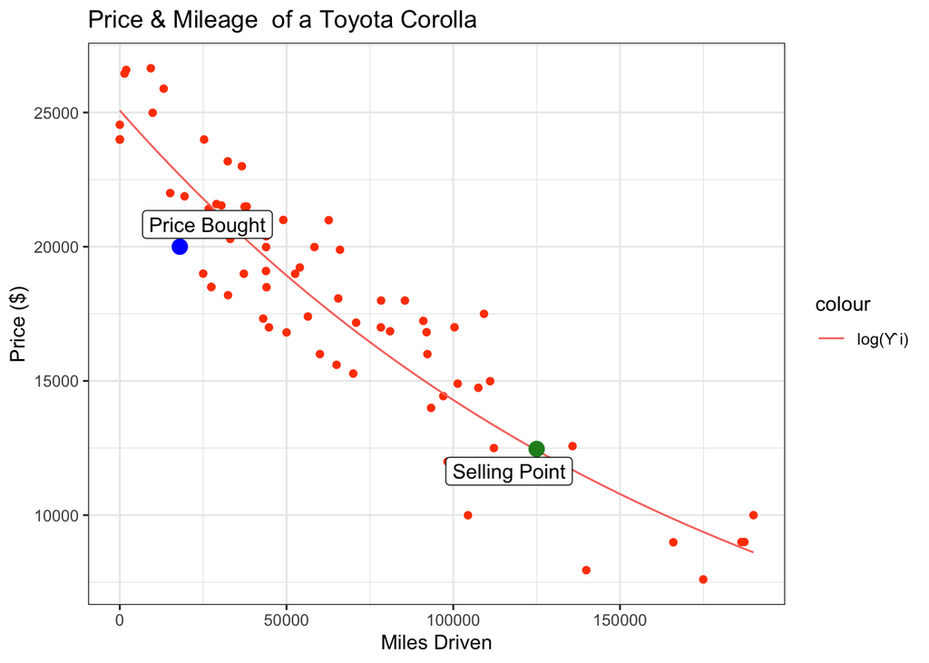

```r
ggplot(mycars, aes(x=Miles, y=Price)) +
  geom_point(colour="orangered") +
  stat_function(fun=function(x) exp(b.log[1] + b.log[2]*x), aes(color="log(Ŷ i)")) +
  geom_point(data = mycars3, mapping = aes(x = Miles, y = Price), col = 'forestgreen', size = 3.5, pch = 19) +
  geom_label_repel(aes(label = Desc), data = mycars3) +
  geom_point(data = mycars2, mapping = aes(x = Miles, y = Price), col = 'blue', size = 3.5, pch = 19) +
  geom_label_repel(aes(label = Desc), data = mycars2) +
  labs(title="Price & Mileage  of a Toyota Corolla", x="Miles Driven", y="Price ($)") +
  theme_bw()
```

## Prediction Intervals

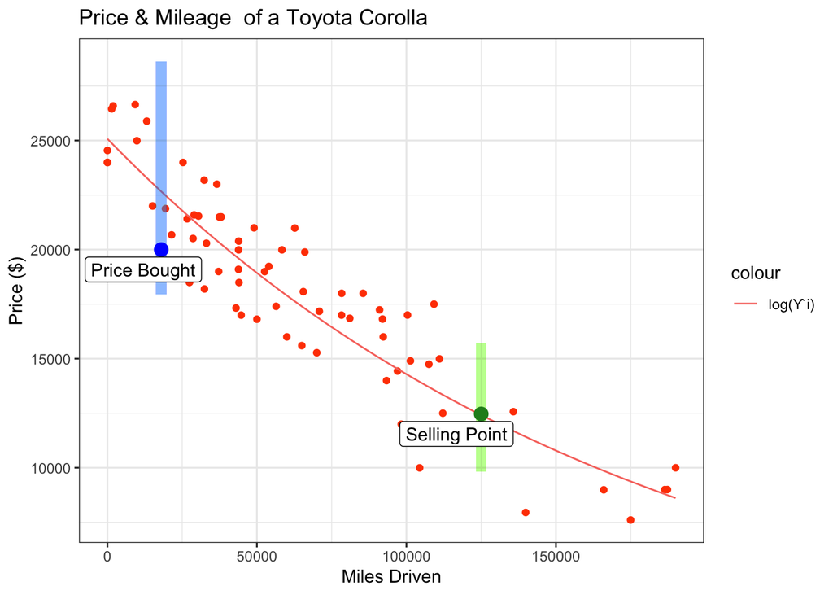

```r
ggplot(mycars, aes(x=Miles, y=Price)) +
  geom_point(colour="orangered") +
  stat_function(fun=function(x) exp(b.log[1] + b.log[2]*x), aes(color="log(Ŷ i)")) +
    geom_segment(aes(x=125000,xend=125000, y=sell_pred[2], yend=sell_pred[3]), alpha=0.01, lwd=3, col="lightgreen") +
  geom_point(data = mycars3, mapping = aes(x = Miles, y = Price), col = 'forestgreen', size = 3.5, pch = 19) +
  geom_label_repel(aes(label = Desc), data = mycars3) +
  geom_segment(aes(x=18000,xend=18000, y=buy_pred[2], yend=buy_pred[3]), alpha=0.01, lwd=3, col="skyblue") +
  geom_point(data = mycars2, mapping = aes(x = Miles, y = Price), col = 'blue', size = 3.5, pch = 19) +
  geom_label_repel(aes(label = Desc), data = mycars2) +
  labs(title="Price & Mileage  of a Toyota Corolla", x="Miles Driven", y="Price ($)") +
  theme_bw()
```

Above, the prediction intervals are shown for both the buying price and the selling price. The blue line shows the prediction interval for the price bought. Further interpreted, this means that I’m 95% confident that an individual data point will lie in this blue line. In other words, 95% of the all 2019 Toyota Corolla SE’s with 18,000 miles driven will lie within the blue line. The values of the prediction interval have a lower limit of 17938.75 and an upper limit of 28632.84 meaning that 95% of any corolla with 18,000 miles driven will be sold within this price range. Continually, the green line shows the prediction interval for the selling point of the corolla. This means that 95% of corollas with 125,000 miles driven will be sold within this green line. The prediction interval has a lower limit of 9,813 and an upper limit of 15,705. Potentially, this means that it’s possible to sell my car at $15,705 when it reaches 125,000 miles to maximize profit.

## Regression Line

In order to understand the estimated value of the car at this point, a simple linear regression will be run. The data gathered includes price bought and mileage (which will be the explanatory variable). This data was found from [**Kelley Blue Book**](https://www.kbb.com/), [**Cars.com**](https://www.cars.com/), & [**KSL.com**](https://cars.ksl.com/).

This analysis attempts to estimate the following regression (the true line):

$$\underbrace{Y_i}_\text{Price} =
{\beta_0} +{\beta_1}
\underbrace{X_i}_\text{Miles} + \epsilon_i \quad \text{where} \
\epsilon_i \sim N(0, \sigma^2)$$

```r
summary(cars.lm)%>%
  pander()
```

|  | Estimate | Std. Error | t value | Pr(>\|t\|) |
| --- | --- | --- | --- | --- |
| **(Intercept)** | 23798 | 381.8 | 62.33 | 2.129e-62 |
| **Miles** | -0.08789 | 0.004861 | -18.08 | 6.991e-28 |

Fitting linear model: Price ~ Miles

| Observations | Residual Std. Error | $R^2$ | Adjusted $R^2$ |
| --- | --- | --- | --- |
| 71 | 1922 | 0.8257 | 0.8232 |

Given the summary table mentioned above, the estimated regression model is interpreted as follows:

$$\underbrace{\hat{Y}_i}_\text{Price} =
{23798} - {0.08789}
\underbrace{X_i}_\text{Miles}$$

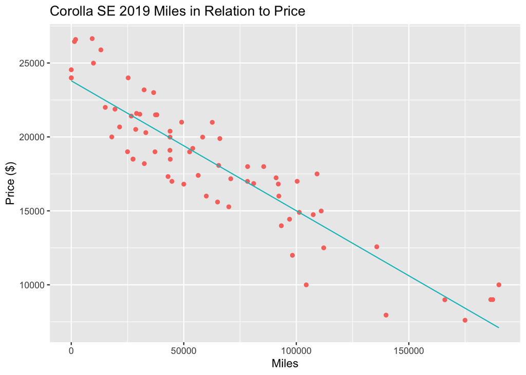

```r
ggplot(mycars, aes(x = Miles, y = Price, col = 'blue')) +
  geom_point() +
  stat_function(fun=function(x) (car.log[1] + car.log[2]*x), aes(color="Y")) +
  theme(legend.position = 'none') +
  labs(y = 'Price ($)', title = 'Corolla SE 2019 Miles in Relation to Price')
```

The summary table shows significant p-values (being less than 0.05 for the intercept and slope). This means that $b_1$ for the estimated regression (which is the slope of miles) is considered significant. However, as you look at the top left of the estimated regression line, it appears that the line doesn’t go through any of the data points at all.The assumptions of the test will now be tested to see the faults.

## Checking the assumptions

Let’s first check the assumptions of linearity and constant variance. The estimated regression line helps us understand the relationship between the x & y variables, which are mileage and price for this data. For a regression line to be valid or credible, it’s essential that the data is linear. Constant variance means that the variance of the residuals are consistent among the data, or in other words that the distance of the residuals to the regression line is consistent among the points. In order to test these, below we are looking at the distance of the residuals to the fitted line (regression line). The regression line is represented by 0 (the grey dotted line). We are hoping to see an even distribution of residuals above and below the regression line, as well as no shapes being formed.

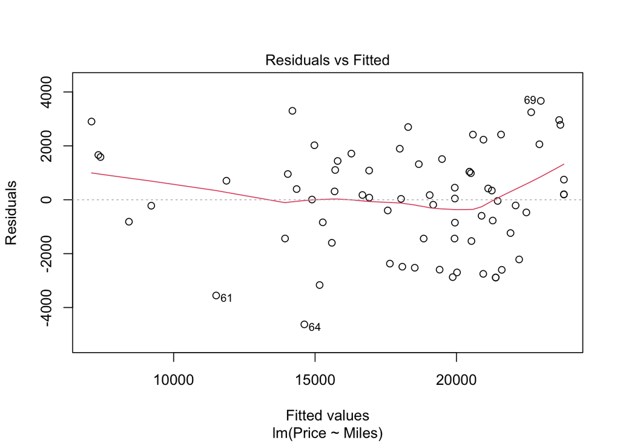

```r
plot(cars.lm, which=1)
```

The points are increasing immensely on the right end, this means that the data is not linear. The constant variance assumption is also not met since there is a trend on the right. This means that we must transform the regression line to fit the data.

## Box Cox

To understand the best transformation for the regression. We will run a box cox test which will help us understand what change(s) we can make in the regression model for it to better fit the data. This gives us a 95% confidence interval of changes that we can do to the regression line for it to better fit the data.

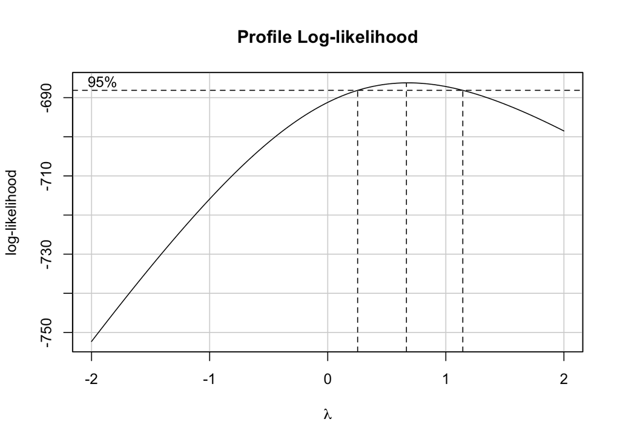

```r
boxCox(cars.lm)
```

## Applying the Transformation

The transformed regression equation can be found below.

$$\log(\hat{Y_i}) = b_0 + b_1*x_i$$

In order for the output to be in interpretable units, we have solved for $\hat{Y_i}$.

$$\hat{Y_i} = e^{b_0} * e^{b_1*x}$$

Below is the new regression line for the model. This was done by using the equation that we solved for above. This is because the price of a car doesn’t decrease in a “linear” manner. In other words, a car will never be worth $0, even if it it’s given to a junkyard for $5 it still has value. It will close to but not touch 0, hence why having a logarithm is important. Below is the transformed regression line (in orange) compared to the original regression line (in blue).

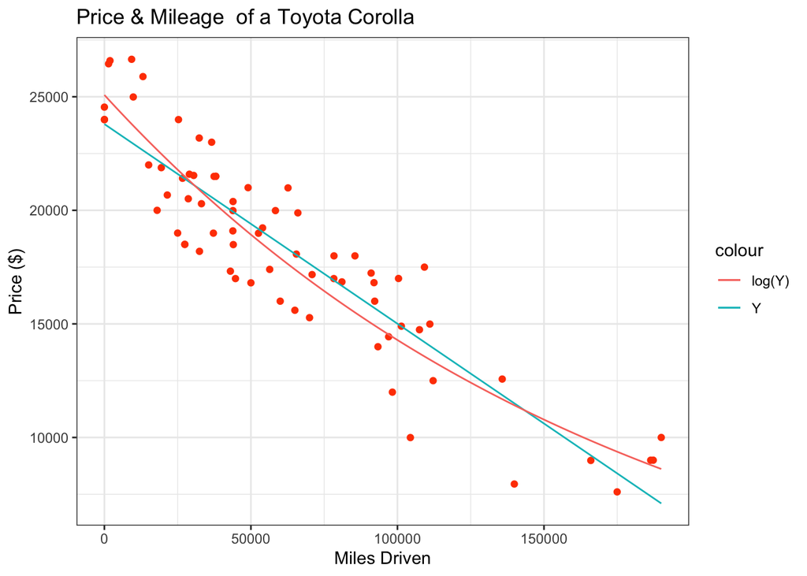

```r
# ggplot code
ggplot(mycars, aes(x=Miles, y=Price)) +
  geom_point(color="orangered") +
  stat_function(fun=function(x) (car.log[1] + car.log[2]*x), aes(color="Y")) +
 stat_function(fun=function(x) exp(b.log[1] + b.log[2]*x), aes(color="log(Y)")) +
  labs(title="Price & Mileage  of a Toyota Corolla", x="Miles Driven", y="Price ($)") +
  theme_bw()
```

The transformed regression line is displayed above in the red line. Initially it already appears to better fit for the data than the initial regression line, seen in blue. Look at the top left of the graph, notice how the red line fits the data better since it goes through more of the data points.

Below is the summary table for the transformed regression line:

```r
summary(mylog) |>
  pander()
```

|  | Estimate | Std. Error | t value | Pr(>\|t\|) |
| --- | --- | --- | --- | --- |
| **(Intercept)** | 10.13 | 0.02297 | 441 | 8.96e-121 |
| **Miles** | -5.625e-06 | 2.925e-07 | -19.23 | 1.981e-29 |

Fitting linear model: log(Price) ~ Miles

| Observations | Residual Std. Error | $R^2$ | Adjusted $R^2$ |
| --- | --- | --- | --- |
| 71 | 0.1156 | 0.8428 | 0.8405 |

The new estimated regression line can be seen below:

$$\underbrace{\hat{Y}_i}_\text{Price} = e^({1.013e+01)} *
e^{(-5.625e-06)*x_i}$$

The p-values are also significant in the summary table for both the intercept and for miles. This means that the intercept and slope are significant for the model. More importantly, look at the p-value of the Miles (which represents the slope). This is even more significant than the original regression model shown above. Let’s further interpret what this means.

## Understanding the Model

The reason that it was preferred for the model to be transformed to a logarithm is because it is more interpretable.

$$e^{b_1}=0.9999944$$

$$e^{b_1*200,000} = 0.324665$$
$$25078.35*e^{5.6e-06}=0.1404388$$

Above shows the decrease in value when the Toyota corolla has been driven for 200,000 miles. This means that after driving 200,000 miles, the car is worth 32.47% of what it was than when it was first bought. That’s a big difference! In other words, every mile driven decreases the value of the corolla by 14 cents.Now let’s check the same assumptions as above to see how it fits the data.

## Revaluating Assumptions

Below is the chart that shows more insight on the linearity assumption and constant variance assumption. As before, we are looking to see that the data points are evenly distributed above and below the regression line (which is represented by the dotted line of 0). This would mean that the residuals are consistent with the transformed regression model. In other words, the transformed regression model is better at estimating the price of the corolla. Continually, we are also looking for no patterns in the residuals, which would show constant variance.

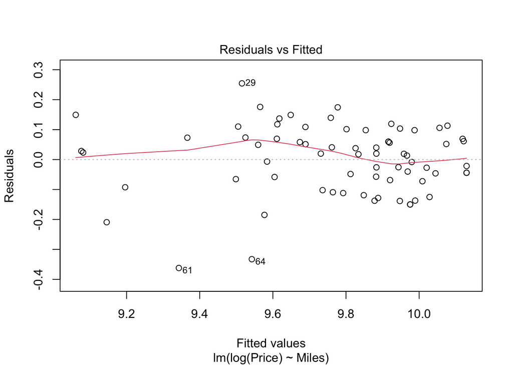

```r
plot(mylog, which=1)
```

The data seems to be a lot more evenly dispersed above and below the regression line which would mean that the relationship between price and mileage shows to fit the logarithmic transformation instead of a linear one.

Ultimately, let’s check that last assumptions about the regression model.

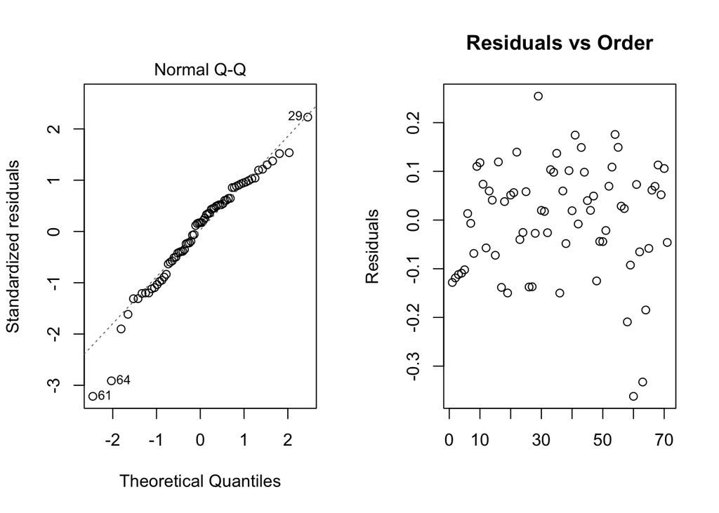

```r
par(mfrow=c(1,2))
plot(mylog, which=2)
plot(mylog$residuals, main="Residuals vs Order", xlab="",
     ylab="Residuals")
```

[« Home](https://k32462.github.io/wdd130-1/Personal_project/MyProject/testingstuff1.html) [Covid Analysis »](https://k32462.github.io/wdd130-1/Personal_project/MyProject/SemesterProject.html) ‹ ›